# EviewsR: Seamless Integration of Eviews and R

Sagiru Mati

2022-07-06

# About EviewsR

EviewsR is an R package that can run Eviews program from R. It also adds `eviews` as knit-engine to `knitr` package.

# Installation

EviewsR can be installed using the following commands in R.

```r
install.packages("EviewsR")

            OR

devtools::install_github('sagirumati/EviewsR')
```

# Setup

To run the package successfully, you need to do one of the following

- Don’t do anything if the name of EViews executable is one of the following: `EViews12_x64`, `EViews12_x86`, `EViews11_x64`, `EViews11_x86`, `EViews10`. The package will find the executable automatically.
- Rename the Eviews executable to `eviews` or one of the names above.
- Alternatively, you can use `set_eviews_path` function to set the path the EViews executable as follows:

```r
set_eviews_path("C:/Program Files (x86)/EViews 10/EViews10.exe")
```

# Usage

Please load the EviewsR package as follows:

````
```{r}                                                                .
library(EviewsR)
```
````

# Creating a workfile from R

An Eviews workfile can be created using `eviews_wfcreate` function in R.

```r
eviews_wfcreate(wf="EviewsR_workfile",page="EviewsR_page",frequency = "m",
start_date = "1990",end_date = "2022")
```

# Eviews chunk

A chunk for Eviews can be created by supplying `eviews` as the engine name as shown below:

````
```{eviews EviewsR,eval=T}
    'This program is created in R Markdown with the help of EviewsR package

  wfcreate(page=EviewsR_page,wf=EviewsR_workfile) m 2000 2022
  for %y EviewsR package page1 page2
  pagecreate(page={%y}) EviewsR m 2000 2022
  next
  pageselect EviewsR_page
  rndseed 123456
  genr y=rnd
  genr x=rnd
  equation ols.ls y c x
  freeze(EviewsROLS,mode=overwrite) ols
  freeze(EviewsR_Plot,mode=overwrite) y.line
  wfsave EviewsR_workfile
```
````

[output not shown]

[figure not shown]

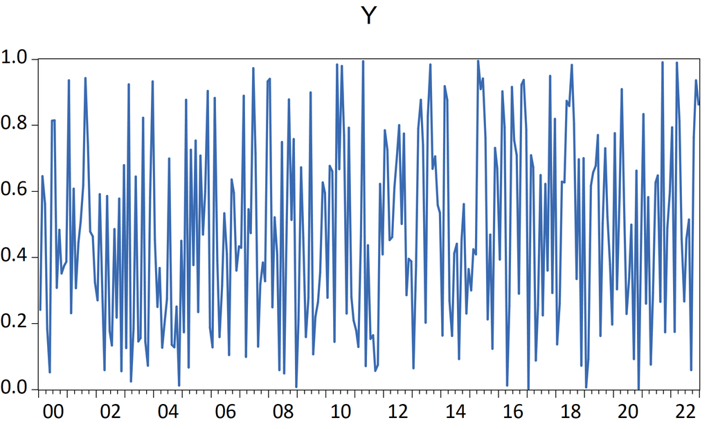

# Executing EViews commands in R

A set of Eviews commands can be executed with the help of `exec_commands` function in R. The above Eviews chunk can be translated using this function.

```r
exec_commands(c('wfcreate(page=EviewsR_page,wf=EviewsR_workfile) m 2000 2022',
  'for %y EviewsR package page1 page2',
  'pagecreate(page={%y}) EviewsR m 2000 2022',
  'next',
'  pageselect EviewsR_page',
  'rndseed 123456',
'  genr y=rnd',
  'genr x=rnd',
  'equation ols.ls y c x',
  'freeze(EviewsROLS,mode=overwrite) ols',
  'freeze(EviewsR_Plot,mode=overwrite) y.line',
  'wfsave EviewsR_workfile',
  'exit'))
```

# Simulation of random walk

A set of random walk series can be simulated in R using EViews engine, thanks to `rwalk` function.

```r
rwalk(wf="eviewsr_workfile",series="X Y Z",page="",rndseed=12345,frequency="M",num_observations=100)
```

# Creating EViews object

The function `create_object` can be used to create an Eviews object in the existing EViews workfile.

```r
create_object(wf="EviewsR_workfile",action="equation",action_opt="",object_name="eviews_equation",view_or_proc="ls",options_list="",arg_list="y ar(1)")
```

# Importing table as kable

Eviews tables can be imported as `kable` object by `import_table` function. Therefore, we can include the results of the OLS generated by the Eviews chunk using the following R chunk;

For the OLS result only:

```r
# options(knitr.kable.NA = '')
import_table(wf="EViewsR_workfile",page="EviewsR_page",table_name = "EViewsrOLS",table_range = "r7c1:r10c5",digits=3)
```

| Variable | Coefficient | Std. Error | t-Statistic | Prob. |
| --- | --- | --- | --- | --- |
| C | 0.496 | 0.033 | 14.882 | 0.000 |
| X | -0.033 | 0.059 | -0.559 | 0.577 |

# Saving EViews workfile

An EViews workfile can be saved various output formats using `eviews_wfsave` in function in R.

```r
eviews_wfsave(wf="eviewsr_workfile",source_description = "EviewsR_wfsave.csv")
```

# Saving EViews page

Similar to Eviews workfile, an Eviews page can be saved in various formats by `eviews_pagesave` function.

```r
eviews_pagesave(wf="eviewsr_workfile",source_description = "EviewsR_pagesave.csv",drop_list = "y")
```

# Importing data to EViews

Data can be imported from external sources by `eviews_import` function.

```r
eviews_import(wf="eviewsr_workfile",source_description = "EviewsR_pagesave.csv")
```

# Import data from EViews

Use `import` function to import data from EViews to R as a dataframe. The function creates a new environment `eviews`, whose objects can be accessed via `eviews$object_name`.

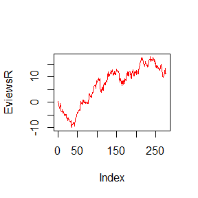

```r
import(object_name = "import",wf="eviewsr_workfile",keep_list = c("x","y"))
plot(eviews$import$y,type="l",ylab="EviewsR",col="red")
```

# Exporting dataframe to EViews

Use `export` function to export dataframe object to Eviews.

```r
export(wf="eviewr_export",source_description=eviews$import,start_date = '1990',frequency = "m")
```

# EViews graph

EViews graph can be included in R Markdown or Quarto document by `eviews_graph` function.

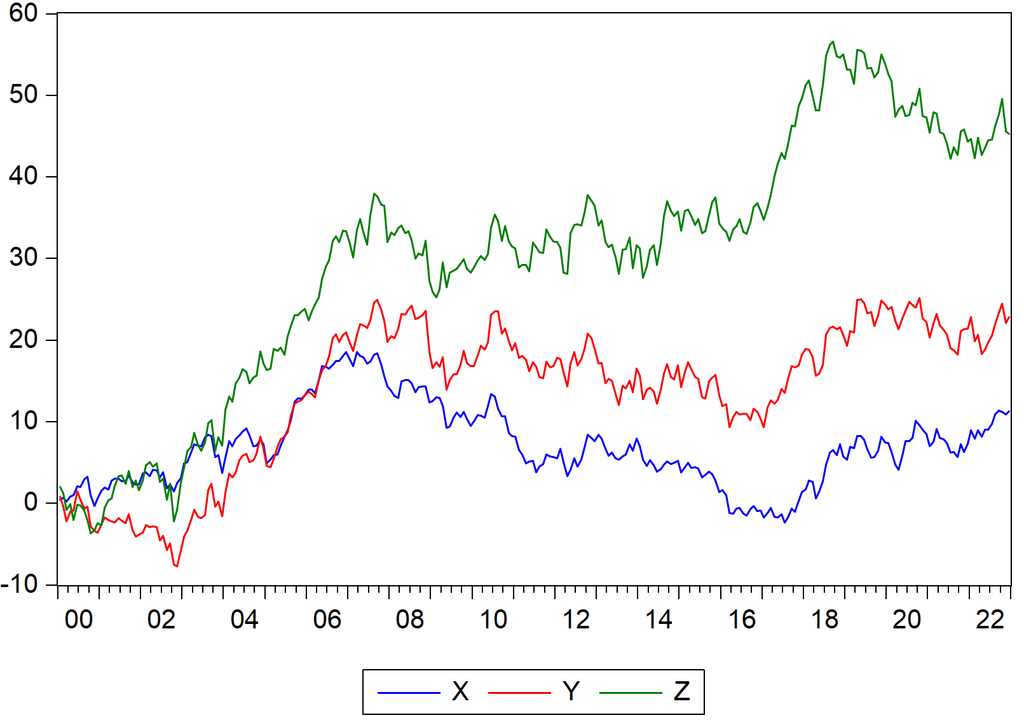

EviewsR example figure

```r
y=runif(100)
x=runif(100)
uu=data.frame(x,y)

 eviews_graph(wf="EviewsR_workfile",page = "EviewsR_page",series="x y z",mode = "overwrite",options = "s",group =T)
```

```r
  # eviews_graph(wf="EviewsR_workfile",page = "EviewsR_page",series="x y",mode = "overwrite",options = "m",merge_graphs =F,start_date="1",frequency="5",save_path = '')
```

# Demo

The demo files are included and can be accessed via demo(package=“EviewsR”)

```r
demo(create_object())
```

```
#>
#>
#>  demo(create_object)
#>  ---- ~~~~~~~~~~~~~
#>
#> > library(EviewsR)
#>
#> > demo(exec_commands)
#>
#>
#>  demo(exec_commands)
#>  ---- ~~~~~~~~~~~~~
#>
#> > library(EviewsR)
#>
#> > # The first example creates an `EViews` workfile with monthly frequency from 1990 2021,
#> > # then save the workfile in the current working directory
#> >
#> > exec_commands(c("wfcreate(wf=EviewsR_exec_commands,page=Page) m 2000 2022",
#> +                 "save EviewsR_exec_commands","exit"))
#>
#> > # The second example opens the `EViews` workfile and then generate a random series
#> > # named `y` and plots its line graph. It also freezes `ols` equation as `EviewsROLS`
#> >
#> > eviewsCommands=r'(genr y=rnd
#> + genr x=rnd
#> + equation ols.ls y c x
#> + freeze(EviewsROLS,mode=overwrite) ols)'
#>
#> > exec_commands(commands=eviewsCommands,wf="EviewsR_exec_commands")
#>
#> > # unlink("EviewsR_exec_commands.wf1")
#>
#> > create_object(wf="EviewsR_exec_commands",action="equation",action_opt="",
#> + object_name="EviewsR_create_object",view_or_proc="ls",options_list="",arg_list="y ar(1)")
```

```r
demo(eviews_graph())
```

```
#>
#>
#>  demo(eviews_graph)
#>  ---- ~~~~~~~~~~~~
#>
#> > library(EviewsR)
#>
#> > demo(exec_commands)
#>
#>
#>  demo(exec_commands)
#>  ---- ~~~~~~~~~~~~~
#>
#> > library(EviewsR)
#>
#> > # The first example creates an `EViews` workfile with monthly frequency from 1990 2021,
#> > # then save the workfile in the current working directory
#> >
#> > exec_commands(c("wfcreate(wf=EviewsR_exec_commands,page=Page) m 2000 2022",
#> +                 "save EviewsR_exec_commands","exit"))
#>
#> > # The second example opens the `EViews` workfile and then generate a random series
#> > # named `y` and plots its line graph. It also freezes `ols` equation as `EviewsROLS`
#> >
#> > eviewsCommands=r'(genr y=rnd
#> + genr x=rnd
#> + equation ols.ls y c x
#> + freeze(EviewsROLS,mode=overwrite) ols)'
#>
#> > exec_commands(commands=eviewsCommands,wf="EviewsR_exec_commands")
#>
#> > # unlink("EviewsR_exec_commands.wf1")
#>
#> > eviews_graph(wf="EviewsR_exec_commands",page = "page",series="x y",mode = "overwrite",options = "m")
#> [1] "EviewsR_files/figure-html//demo-page-X.png"
#> [2] "EviewsR_files/figure-html//demo-page-Y.png"
#> attr(,"class")
#> [1] "knit_image_paths" "knit_asis"
```

```r
demo(eviews_wfcreate())
```

```
#>
#>
#>  demo(eviews_wfcreate)
#>  ---- ~~~~~~~~~~~~~~~
#>
#> > library(EviewsR)
#>
#> > eviews_wfcreate(wf="EviewsR_eviews_wfcreate",page="EviewsR_page",frequency = "m",
#> +                 start_date = "1990",end_date = "2022")
```

# Template

Template for R Markdown is created. Go to `file->New File->R Markdown-> From Template->EviewsR`.

Please download the example files from [Github](https://github.com/sagirumati/EviewsR/tree/master/inst/examples/).